# Ex2: Adult Dataset

- Adult Dataset được cung cấp bởi UCI (University of California, Irvine) được sử dụng để phát triển mô hình dự đoán Predictive Model Development.
- Bộ dữ liệu adult.data và adult.test chứa 48.842 mẫu và có 14 attributes/features. Dữ liệu này được dùng để xây dựng model dự đoán và kiểm tra một mẫu có thu nhập >50K USD hay không. ### Attribute Information:
- age: continuous.
- workclass: Private, Self-emp-not-inc, Self-emp-inc, Federal-gov, Local-gov, State-gov, Without-pay, Never-worked.
- fnlwgt: continuous.
- education: Bachelors, Some-college, 11th, HS-grad, Prof-school, Assoc-acdm, Assoc-voc, 9th, 7th-8th, 12th, Masters, 1st-4th, 10th, Doctorate, 5th-6th, Preschool.
- education-num: continuous.
- marital-status: Married-civ-spouse, Divorced, Never-married, Separated, Widowed, Married-spouse-absent, Married-AF-spouse.
- occupation: Tech-support, Craft-repair, Other-service, Sales, Exec-managerial, Prof-specialty, Handlers-cleaners, Machine-op-inspct, Adm-clerical, Farming-fishing, Transport-moving, Priv-house-serv, Protective-serv, Armed-Forces.
- relationship: Wife, Own-child, Husband, Not-in-family, Other-relative, Unmarried.
- race: White, Asian-Pac-Islander, Amer-Indian-Eskimo, Other, Black.
- sex: Female, Male.
- capital-gain: continuous.
- capital-loss: continuous.
- hours-per-week: continuous.
- native-country: United-States, Cambodia, England, Puerto-Rico, Canada, Germany, Outlying-US(Guam-USVI-etc), India, Japan, Greece, South, China, Cuba, Iran, Honduras, Philippines, Italy, Poland, Jamaica, Vietnam, Mexico, Portugal, Ireland, France, Dominican-Republic, Laos, Ecuador, Taiwan, Haiti, Columbia, Hungary, Guatemala, Nicaragua, Scotland, Thailand, Yugoslavia, El-Salvador, Trinadad&Tobago, Peru, Hong, Holand-Netherlands.
- Class: >50K, <=50K.

## Yêu cầu:

- Đọc dữ liệu adult.data, tiền xử lý dữ liệu.
- Xem xét tính cân bằng giữa hai loại mẫu. Trực quan hóa. Nhận xét.
- Nếu 2 loại mẫu này không cân bằng, hãy chọn một phương pháp cân bằng dữ liệu và thực hiện. Trực quan hóa kết quả.

```python
# link tham khảo: https://towardsdatascience.com/under-sampling-a-performance-booster-on-imbalanced-data-a79ff1559fab
```

```python
import pandas as pd
import numpy as np
import matplotlib.pyplot as plt
import seaborn as sns
```

```python
# Đọc dữ liệu, kiểm tra sơ bộ bau đầu, trực quan hóa, tiền xử lý dữ liệu
adult_train = pd.read_csv("adult/adult.data", header=None)
```

```python
adult_train.head()
```

|  | 0 | 1 | 2 | 3 | 4 | 5 | 6 | 7 | 8 | 9 | 10 | 11 | 12 | 13 | 14 |
| --- | --- | --- | --- | --- | --- | --- | --- | --- | --- | --- | --- | --- | --- | --- | --- |
| 0 | 39 | State-gov | 77516 | Bachelors | 13 | Never-married | Adm-clerical | Not-in-family | White | Male | 2174 | 0 | 40 | United-States | <=50K |
| 1 | 50 | Self-emp-not-inc | 83311 | Bachelors | 13 | Married-civ-spouse | Exec-managerial | Husband | White | Male | 0 | 0 | 13 | United-States | <=50K |
| 2 | 38 | Private | 215646 | HS-grad | 9 | Divorced | Handlers-cleaners | Not-in-family | White | Male | 0 | 0 | 40 | United-States | <=50K |
| 3 | 53 | Private | 234721 | 11th | 7 | Married-civ-spouse | Handlers-cleaners | Husband | Black | Male | 0 | 0 | 40 | United-States | <=50K |
| 4 | 28 | Private | 338409 | Bachelors | 13 | Married-civ-spouse | Prof-specialty | Wife | Black | Female | 0 | 0 | 40 | Cuba | <=50K |

```python
adult_train.info()
```

```
<class 'pandas.core.frame.DataFrame'>
RangeIndex: 32561 entries, 0 to 32560
Data columns (total 15 columns):
0     32561 non-null int64
1     32561 non-null object
2     32561 non-null int64
3     32561 non-null object
4     32561 non-null int64
5     32561 non-null object
6     32561 non-null object
7     32561 non-null object
8     32561 non-null object
9     32561 non-null object
10    32561 non-null int64
11    32561 non-null int64
12    32561 non-null int64
13    32561 non-null object
14    32561 non-null object
dtypes: int64(6), object(9)
memory usage: 3.7+ MB
```

```python
adult_train.to_csv("aldult_data.csv")
```

```python
# Không có dữ liệu null
```

```python
# Đếm theo loại: hiếm, phổ biến
occ = adult_train[14].value_counts()
occ
```

```
 <=50K    24720
 >50K      7841
Name: 14, dtype: int64
```

```
<BarContainer object of 2 artists>
```

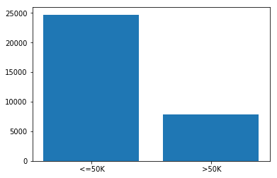

```python
plt.bar(occ.index.values, occ.values)
```

```python
# Chuyển dữ liệu phân loại thành dạng numeric dùng Label encoder và dummy encoder
```

```python
y_train = adult_train[14]
X_train = adult_train.drop([14], axis=1)
```

```python
X_train.head(2)
```

|  | 0 | 1 | 2 | 3 | 4 | 5 | 6 | 7 | 8 | 9 | 10 | 11 | 12 | 13 |
| --- | --- | --- | --- | --- | --- | --- | --- | --- | --- | --- | --- | --- | --- | --- |
| 0 | 39 | State-gov | 77516 | Bachelors | 13 | Never-married | Adm-clerical | Not-in-family | White | Male | 2174 | 0 | 40 | United-States |
| 1 | 50 | Self-emp-not-inc | 83311 | Bachelors | 13 | Married-civ-spouse | Exec-managerial | Husband | White | Male | 0 | 0 | 13 | United-States |

```python
y_train[:2]
```

```
0     <=50K
1     <=50K
Name: 14, dtype: object
```

```python
from sklearn.preprocessing import LabelEncoder
```

```python
label_encoder = LabelEncoder()
y_train_l = label_encoder.fit_transform(y_train)
```

```python
y_train_l[:2]
```

```
array([0, 0])
```

```python
# Categorical boolean mask
categorical_feature_mask = X_train.dtypes==object
# filter categorical columns using mask and turn it into a list
categorical_cols = X_train.columns[categorical_feature_mask].tolist()
categorical_cols
```

```
[1, 3, 5, 6, 7, 8, 9, 13]
```

```python
X_train_d = pd.get_dummies(data=X_train, columns=categorical_cols, drop_first=True)
```

```python
X_train_d.head(2)
```

|  | 0 | 2 | 4 | 10 | 11 | 12 | 1_ Federal-gov | 1_ Local-gov | 1_ Never-worked | 1_ Private | ... | 13_ Portugal | 13_ Puerto-Rico | 13_ Scotland | 13_ South | 13_ Taiwan | 13_ Thailand | 13_ Trinadad&Tobago | 13_ United-States | 13_ Vietnam | 13_ Yugoslavia |
| --- | --- | --- | --- | --- | --- | --- | --- | --- | --- | --- | --- | --- | --- | --- | --- | --- | --- | --- | --- | --- | --- |
| 0 | 39 | 77516 | 13 | 2174 | 0 | 40 | 0 | 0 | 0 | 0 | ... | 0 | 0 | 0 | 0 | 0 | 0 | 0 | 1 | 0 | 0 |
| 1 | 50 | 83311 | 13 | 0 | 0 | 13 | 0 | 0 | 0 | 0 | ... | 0 | 0 | 0 | 0 | 0 | 0 | 0 | 1 | 0 | 0 |

2 rows × 100 columns

```python
from collections import Counter
sorted(Counter(y_train_l).items())
```

```
[(0, 24720), (1, 7841)]
```

```python
# Vì lượng dữ liệu class 1 tương đối nhiều => do đó ta sẽ áp dụng Udersampling
# để giảm số mẫu của nhóm <=50k bằng với nhóm >50k
```

```python
from sklearn.utils import resample
```

```python
# có thể dùng cách resample
```

```python
data_train = X_train_d
data_train[14] = y_train_l
```

```python
data_0 = data_train[data_train[14]==0]
data_1 = data_train[data_train[14]==1]
```

```python
display(data_0.shape, data_1.shape)
```

```
(24720, 101)
```

```
(7841, 101)
```

```python
from sklearn.utils import resample
```

```python
data_0_resample = resample(data_0,
                       replace = False, # sample without replacement
                       n_samples = data_1.shape[0], # match minority n
                       random_state = 27) # reproducible results
```

```python
downsampled = pd.concat([data_0_resample, data_1])
downsampled.head()
```

|  | 0 | 2 | 4 | 10 | 11 | 12 | 1_ Federal-gov | 1_ Local-gov | 1_ Never-worked | 1_ Private | ... | 13_ Puerto-Rico | 13_ Scotland | 13_ South | 13_ Taiwan | 13_ Thailand | 13_ Trinadad&Tobago | 13_ United-States | 13_ Vietnam | 13_ Yugoslavia | 14 |
| --- | --- | --- | --- | --- | --- | --- | --- | --- | --- | --- | --- | --- | --- | --- | --- | --- | --- | --- | --- | --- | --- |
| 31749 | 22 | 199426 | 10 | 0 | 0 | 17 | 0 | 0 | 0 | 1 | ... | 0 | 0 | 0 | 0 | 0 | 0 | 1 | 0 | 0 | 0 |
| 24093 | 31 | 91964 | 13 | 0 | 0 | 40 | 0 | 0 | 0 | 1 | ... | 0 | 0 | 0 | 0 | 0 | 0 | 1 | 0 | 0 | 0 |
| 21539 | 37 | 60313 | 9 | 0 | 0 | 40 | 0 | 0 | 0 | 1 | ... | 0 | 0 | 0 | 0 | 0 | 0 | 1 | 0 | 0 | 0 |
| 24582 | 30 | 85708 | 9 | 0 | 0 | 40 | 0 | 0 | 0 | 1 | ... | 0 | 0 | 0 | 0 | 0 | 0 | 1 | 0 | 0 | 0 |
| 622 | 65 | 109351 | 5 | 0 | 0 | 24 | 0 | 0 | 0 | 1 | ... | 0 | 0 | 0 | 0 | 0 | 0 | 1 | 0 | 0 | 0 |

5 rows × 101 columns

```python
display(data_0_resample.shape, data_1.shape)
```

```
(7841, 101)
```

```
(7841, 101)
```